# Unsupervised Learning

- K-means
- Hierarchical Clustering
- GMM
- DBScan

# Dataset

- Wine Dataset

```python
from sklearn.datasets import load_wine
wine_data = load_wine()
```

## Wine Dataset

```python
print (wine_data.DESCR)
```

```
.. _wine_dataset:

Wine recognition dataset
------------------------

**Data Set Characteristics:**

    :Number of Instances: 178 (50 in each of three classes)
    :Number of Attributes: 13 numeric, predictive attributes and the class
    :Attribute Information:
 		- Alcohol
 		- Malic acid
 		- Ash
		- Alcalinity of ash
 		- Magnesium
		- Total phenols
 		- Flavanoids
 		- Nonflavanoid phenols
 		- Proanthocyanins
		- Color intensity
 		- Hue
 		- OD280/OD315 of diluted wines
 		- Proline

    - class:
            - class_0
            - class_1
            - class_2

    :Summary Statistics:

    ============================= ==== ===== ======= =====
                                   Min   Max   Mean     SD
    ============================= ==== ===== ======= =====
    Alcohol:                      11.0  14.8    13.0   0.8
    Malic Acid:                   0.74  5.80    2.34  1.12
    Ash:                          1.36  3.23    2.36  0.27
    Alcalinity of Ash:            10.6  30.0    19.5   3.3
    Magnesium:                    70.0 162.0    99.7  14.3
    Total Phenols:                0.98  3.88    2.29  0.63
```

[output cut: 40 more lines]

```
  Tech. Rep. no. 92-02, (1992), Dept. of Computer Science and Dept. of
  Mathematics and Statistics, James Cook University of North Queensland.
  (Also submitted to Technometrics).

  The data was used with many others for comparing various
  classifiers. The classes are separable, though only RDA
  has achieved 100% correct classification.
  (RDA : 100%, QDA 99.4%, LDA 98.9%, 1NN 96.1% (z-transformed data))
  (All results using the leave-one-out technique)

  (2) S. Aeberhard, D. Coomans and O. de Vel,
  "THE CLASSIFICATION PERFORMANCE OF RDA"
  Tech. Rep. no. 92-01, (1992), Dept. of Computer Science and Dept. of
  Mathematics and Statistics, James Cook University of North Queensland.
  (Also submitted to Journal of Chemometrics).
```

```python
print (wine_data.data)
```

```
[[1.423e+01 1.710e+00 2.430e+00 ... 1.040e+00 3.920e+00 1.065e+03]
 [1.320e+01 1.780e+00 2.140e+00 ... 1.050e+00 3.400e+00 1.050e+03]
 [1.316e+01 2.360e+00 2.670e+00 ... 1.030e+00 3.170e+00 1.185e+03]
 ...
 [1.327e+01 4.280e+00 2.260e+00 ... 5.900e-01 1.560e+00 8.350e+02]
 [1.317e+01 2.590e+00 2.370e+00 ... 6.000e-01 1.620e+00 8.400e+02]
 [1.413e+01 4.100e+00 2.740e+00 ... 6.100e-01 1.600e+00 5.600e+02]]
```

## Types of Input Data

- One Mode Matrix
- Two Mode Matrix

## Dissimilarity Matrix ( One mode matrix)

- object by object
- n * n matrix

How do we transform two mode data into one mode data

L1 (manhattan) $|x_{1}-x_{2}|+|y_{1}-y_{2}|.$

L2 (euclidean) $\sqrt{(x_{1}-x_{2})^{2}+(y_{1}-y_{2})^{2}}.$

cosine $\frac {x \cdot y}{||x|| \cdot ||y||}$

we can use sklearn.metrics.pairwise

```python
from sklearn.metrics import pairwise
#manhattan
one_mode_L1_data = pairwise.manhattan_distances(load_wine().data,load_wine().data)
#euclidean
one_mode_L2_data = pairwise.euclidean_distances(load_wine().data,load_wine().data)
```

```python
print (one_mode_L1_data.shape)
print (one_mode_L1_data[0])
print (one_mode_L2_data[0])
```

```
(178, 178)
[  0.        51.06     152.48     435.09     349.97     403.87
 259.26     241.56      54.48      53.04     471.74     252.49
 296.08     129.02     515.66     266.56     229.28      85.71
 641.3      235.56     287.61     329.54      60.71      89.69
 260.06     253.69     168.32     260.71     177.45      64.34
 255.79     478.21     104.59     182.82      55.72     179.39
 207.33      77.48      80.85     312.36     283.2       77.42
  59.67     417.98     204.82      39.34      29.47     109.1
  34.75     221.24     128.46     236.5      147.38     327.33
  17.66      73.86     107.04     235.15     244.87     603.68
 423.84     652.4      478.99     694.78     747.26     424.89
 616.64     615.4      343.78     382.38     235.544    710.39
 648.89     111.9      218.98     678.34     722.51     594.95
 334.42     644.16     841.19     401.35     503.41     608.91
 589.01     654.42     624.9      562.68     444.38     515.42
 644.86     672.2      632.51     825.38     759.98     175.15
 465.07     687.54     453.81     709.64     396.05     555.77
 669.91     705.71     447.73     803.54     613.67     636.18
 800.12     429.79     538.64     794.14     497.42     685.85
 738.43     716.74     626.72     755.12     753.       556.85
 482.91     628.42     747.47     742.53     744.59     742.61
 765.93     656.62     779.48     550.96     453.21     572.94
 552.54     503.39     468.8      417.9      403.98     604.21
 538.62     519.53     512.6      336.73     594.41     566.09
 242.02     277.88     715.34     500.91     468.34     549.4
 589.75     621.11     670.14     436.39     465.53     394.75
 640.03     239.01     456.01     502.02     602.38     419.2
 532.79     425.12     506.77     603.12     408.15     438.37
 357.45     472.89     601.27     655.019999 457.7      376.06
 359.18     257.14     249.41     558.28    ]
[  0.          31.26501239 122.83115403 415.24539985 330.17450008
 385.29595988 227.12947365 230.09159915  36.11696554  35.27497697
 445.55102603 217.37853919 257.81932782  92.41866695 482.66694273
 245.47425934 215.16396492  66.27069714 615.30369055 220.28274694
 285.00237596 296.08653769  39.76334116  59.45622844 222.22987738
 235.22246598 134.38352354 222.48120977 151.38254952  43.1612998
 221.64284672 450.50692703  78.49626552 170.12507517  34.71830353
 147.57804274 185.79160934  49.53119219  53.60958403 305.02052718
 270.18798012  47.83493911  39.71841512 385.76405328 181.11953677
```

[output cut: 12 more lines]

```
 750.95051222 557.0080661  578.65347783 753.83074546 386.45811196
 503.43543797 741.06009932 458.66750855 632.24295528 681.404159
 659.38587003 571.5168008  720.29697972 694.6068131  502.63634538
 441.12913223 600.20240453 700.54941746 686.27203782 686.51301015
 688.31455883 714.20765545 600.17440765 724.11827791 487.34043809
 435.05621832 535.5286997  505.91933547 465.53272678 417.14472836
 371.507043   347.17786565 550.98164697 486.60039355 475.80173991
 466.08202583 287.58183131 545.89959342 516.22929411 210.62068512
 236.43336567 651.73644673 441.97704115 416.54339198 515.25629273
 565.09752335 585.26284206 640.18238745 391.13817469 425.72501136
 341.80278802 586.27083733 187.82095969 406.22157882 446.72507205
 546.44244015 385.56581747 495.5036574  390.60007629 451.59861614
 546.45862057 370.47653866 382.06856126 315.92756654 435.39221089
 555.89515459 596.45510493 406.65772291 326.66004929 316.11052687
 230.24002302 225.21518399 506.05936766]
```

## Data Matrix (Two mode Matrix)

n objects with p attributes

n * p matrix

```python
two_mode_data = load_wine().data
print (two_mode_data)
print (two_mode_data.shape)
```

```
[[1.423e+01 1.710e+00 2.430e+00 ... 1.040e+00 3.920e+00 1.065e+03]
 [1.320e+01 1.780e+00 2.140e+00 ... 1.050e+00 3.400e+00 1.050e+03]
 [1.316e+01 2.360e+00 2.670e+00 ... 1.030e+00 3.170e+00 1.185e+03]
 ...
 [1.327e+01 4.280e+00 2.260e+00 ... 5.900e-01 1.560e+00 8.350e+02]
 [1.317e+01 2.590e+00 2.370e+00 ... 6.000e-01 1.620e+00 8.400e+02]
 [1.413e+01 4.100e+00 2.740e+00 ... 6.100e-01 1.600e+00 5.600e+02]]
(178, 13)
```

## K-Means

- sklearn.cluster.Kmeans
- input
  - k clusters
  - data (n object with p attribute)

n_clusters  
the number of clusters to form as well as the number of centroids to generate  
random_state

```python
from sklearn.cluster import KMeans
from sklearn.preprocessing import MinMaxScaler
kmeans_data = MinMaxScaler().fit_transform(two_mode_data)
kmeans = KMeans(n_clusters=3, random_state=0).fit(kmeans_data)
print (kmeans.labels_)
```

```
[0 0 0 0 0 0 0 0 0 0 0 0 0 0 0 0 0 0 0 0 0 0 0 0 0 0 0 0 0 0 0 0 0 0 0 0 0
 0 0 0 0 0 0 0 0 0 0 0 0 0 0 0 0 0 0 0 0 0 0 2 1 1 2 2 2 2 2 2 1 2 1 2 2 0
 2 2 2 2 2 2 2 2 2 1 2 2 2 2 2 2 2 2 1 2 2 0 2 2 2 2 2 2 2 2 2 2 2 2 2 2 2
 2 2 2 2 2 2 2 1 2 2 2 2 2 2 2 2 2 2 2 1 1 1 1 1 1 1 1 1 1 1 1 1 1 1 1 1 1
 1 1 1 1 1 1 1 1 1 1 1 1 1 1 1 1 1 1 1 1 1 1 1 1 1 1 1 1 1 1]
```

```python
from sklearn.manifold import TSNE

model = TSNE(n_components=2, random_state=0)
result = model.fit_transform(kmeans_data)
print (result)
```

```
[[-9.41307545e+00 -5.36982441e+00]
 [-5.27640247e+00 -5.49918079e+00]
 [-7.33208895e+00 -8.36583614e+00]
 [-9.86803055e+00 -8.85849667e+00]
 [-2.71293235e+00 -8.07800102e+00]
 [-8.74751949e+00 -9.56701660e+00]
 [-6.87087154e+00 -6.61375618e+00]
 [-6.07435513e+00 -6.53456926e+00]
 [-7.68953991e+00 -7.03216743e+00]
 [-8.51977444e+00 -6.58942795e+00]
 [-7.97146225e+00 -9.49195194e+00]
 [-5.53940439e+00 -6.96382809e+00]
 [-6.14226818e+00 -7.58807802e+00]
 [-9.94132137e+00 -1.05815887e+01]
 [-9.56696224e+00 -1.01469898e+01]
 [-5.87846708e+00 -9.06414223e+00]
 [-6.34167147e+00 -9.82225227e+00]
 [-5.71603203e+00 -9.83495331e+00]
 [-8.52365685e+00 -1.03194447e+01]
 [-7.94164467e+00 -3.64376426e+00]
 [-9.13688850e+00 -5.25335646e+00]
 [-6.13593769e+00 -2.62695193e+00]
 [-6.45533419e+00 -5.23342800e+00]
 [-5.27841616e+00 -4.71946764e+00]
 [-5.62069654e+00 -4.52530670e+00]
 [-2.25526690e+00 -8.29965019e+00]
 [-5.51274776e+00 -7.56508780e+00]
 [-4.55233908e+00 -6.10934210e+00]
 [-3.93887067e+00 -8.34850216e+00]
 [-6.96671963e+00 -5.86230040e+00]
 [-6.87722206e+00 -9.54773331e+00]
 [-7.72863102e+00 -9.33568954e+00]
 [-4.41442728e+00 -7.77206182e+00]
 [-4.72162676e+00 -9.87759686e+00]
 [-4.51377773e+00 -7.14347553e+00]
 [-6.30863476e+00 -4.99403048e+00]
 [-3.80580735e+00 -7.34558010e+00]
 [-4.16054487e+00 -6.64207315e+00]
 [-4.08926249e+00 -5.78821754e+00]
 [-8.50391388e+00 -3.38012290e+00]
```

[output cut: 123 more lines]

```
 [ 9.20722485e+00  9.89115810e+00]
 [ 9.06734848e+00  1.20329800e+01]
 [ 1.14944992e+01  1.02923317e+01]
 [ 9.65223980e+00  1.28086529e+01]
 [ 9.20773888e+00  1.15515003e+01]
 [ 8.94358253e+00  1.28257837e+01]
 [ 9.89676476e+00  1.44290972e+01]
 [ 8.72419167e+00  9.59697056e+00]
 [ 8.50311947e+00  1.09170380e+01]
 [ 8.88660622e+00  1.21004219e+01]
 [ 1.18410072e+01  1.12449503e+01]
 [ 1.01385603e+01  1.18877850e+01]
 [ 1.01812410e+01  1.29515247e+01]
 [ 8.11066532e+00  1.17585115e+01]
 [ 1.12092991e+01  1.21997452e+01]]
```

```python
from matplotlib.font_manager import FontProperties
import matplotlib.pyplot as plt
import numpy as np
%matplotlib inline
# Get current size
fig_size = plt.rcParams["figure.figsize"]
# Set figure width to 12 and height to 9
fig_size[0] = 4.0
fig_size[1] = 3.0
plt.rcParams["figure.figsize"] = fig_size
```

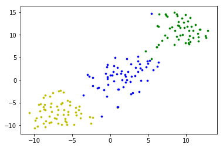

```python
result_0 = np.array([result[i] for i in range(len(kmeans.labels_)) if kmeans.labels_[i] == 0])
result_1 = np.array([result[i] for i in range(len(kmeans.labels_)) if kmeans.labels_[i] == 1])
result_2 = np.array([result[i] for i in range(len(kmeans.labels_)) if kmeans.labels_[i] == 2])

plt.scatter(result_0[:,0], result_0[:,1], c='y', linewidths=0.5, s=10)
plt.scatter(result_1[:,0], result_1[:,1], c='g', linewidths=0.5, s=10)
plt.scatter(result_2[:,0], result_2[:,1], c='b', linewidths=0.5, s=10)
flg_kmeans = plt
```

## Hierarchical Clustering

- sklearn.cluster.AgglomerativeClustering
- input
- data (n objects by n objects)

n_clusters  
The number of clusters to find  
affinity  
Can be 'euclidean'(default), 'l1', 'l2', 'manhattan', 'cosine' or 'precomputed'  
linkage  
'ward', 'complete', 'average'

If linkage is “ward”, only “euclidean” is accepted

```python
from sklearn.cluster import AgglomerativeClustering

L2_hierarchical_1 = AgglomerativeClustering(n_clusters=6, linkage='complete', affinity='l2').fit(two_mode_data)
L2_hierarchical_2 = AgglomerativeClustering(n_clusters=6, linkage='complete',affinity='precomputed').fit(one_mode_L2_data)
print (L2_hierarchical_1.labels_)
print (L2_hierarchical_2.labels_)
```

```
[2 2 2 1 0 1 5 5 2 2 1 5 5 2 1 5 5 2 1 0 0 0 2 2 0 0 2 5 0 2 5 1 0 2 2 0 0
 2 2 0 0 2 2 0 0 2 2 0 2 5 2 5 2 5 2 2 0 5 5 3 0 3 3 4 4 0 3 3 0 0 0 4 3 0
 0 4 4 3 0 3 4 0 3 3 3 3 3 3 0 3 3 3 3 4 4 0 3 4 0 4 0 3 4 4 0 4 3 3 4 0 3
 4 3 4 4 4 3 4 4 3 3 3 4 4 4 4 4 3 4 3 3 3 3 3 0 0 0 3 3 3 3 0 3 3 0 0 4 3
 0 3 3 3 4 0 3 0 3 0 0 3 3 0 3 0 3 3 0 0 0 3 3 3 0 0 0 0 0 3]
[2 2 2 1 0 1 5 5 2 2 1 5 5 2 1 5 5 2 1 0 0 0 2 2 0 0 2 5 0 2 5 1 0 2 2 0 0
 2 2 0 0 2 2 0 0 2 2 0 2 5 2 5 2 5 2 2 0 5 5 3 0 3 3 4 4 0 3 3 0 0 0 4 3 0
 0 4 4 3 0 3 4 0 3 3 3 3 3 3 0 3 3 3 3 4 4 0 3 4 0 4 0 3 4 4 0 4 3 3 4 0 3
 4 3 4 4 4 3 4 4 3 3 3 4 4 4 4 4 3 4 3 3 3 3 3 0 0 0 3 3 3 3 0 3 3 0 0 4 3
 0 3 3 3 4 0 3 0 3 0 0 3 3 0 3 0 3 3 0 0 0 3 3 3 0 0 0 0 0 3]
```

```python
from sklearn.preprocessing import MinMaxScaler
hierarchical_data = MinMaxScaler().fit_transform(two_mode_data)
hierarchical_example = AgglomerativeClustering(n_clusters=3, linkage='complete').fit(hierarchical_data)
```

```python
from sklearn.manifold import TSNE

model = TSNE(n_components=2, random_state=0)
result = model.fit_transform(hierarchical_data)
print (result)
```

```
[[-9.41307545e+00 -5.36982441e+00]
 [-5.27640247e+00 -5.49918079e+00]
 [-7.33208895e+00 -8.36583614e+00]
 [-9.86803055e+00 -8.85849667e+00]
 [-2.71293235e+00 -8.07800102e+00]
 [-8.74751949e+00 -9.56701660e+00]
 [-6.87087154e+00 -6.61375618e+00]
 [-6.07435513e+00 -6.53456926e+00]
 [-7.68953991e+00 -7.03216743e+00]
 [-8.51977444e+00 -6.58942795e+00]
 [-7.97146225e+00 -9.49195194e+00]
 [-5.53940439e+00 -6.96382809e+00]
 [-6.14226818e+00 -7.58807802e+00]
 [-9.94132137e+00 -1.05815887e+01]
 [-9.56696224e+00 -1.01469898e+01]
 [-5.87846708e+00 -9.06414223e+00]
 [-6.34167147e+00 -9.82225227e+00]
 [-5.71603203e+00 -9.83495331e+00]
 [-8.52365685e+00 -1.03194447e+01]
 [-7.94164467e+00 -3.64376426e+00]
 [-9.13688850e+00 -5.25335646e+00]
 [-6.13593769e+00 -2.62695193e+00]
 [-6.45533419e+00 -5.23342800e+00]
 [-5.27841616e+00 -4.71946764e+00]
 [-5.62069654e+00 -4.52530670e+00]
 [-2.25526690e+00 -8.29965019e+00]
 [-5.51274776e+00 -7.56508780e+00]
 [-4.55233908e+00 -6.10934210e+00]
 [-3.93887067e+00 -8.34850216e+00]
 [-6.96671963e+00 -5.86230040e+00]
 [-6.87722206e+00 -9.54773331e+00]
 [-7.72863102e+00 -9.33568954e+00]
 [-4.41442728e+00 -7.77206182e+00]
 [-4.72162676e+00 -9.87759686e+00]
 [-4.51377773e+00 -7.14347553e+00]
 [-6.30863476e+00 -4.99403048e+00]
 [-3.80580735e+00 -7.34558010e+00]
 [-4.16054487e+00 -6.64207315e+00]
 [-4.08926249e+00 -5.78821754e+00]
 [-8.50391388e+00 -3.38012290e+00]
```

[output cut: 123 more lines]

```
 [ 9.20722485e+00  9.89115810e+00]
 [ 9.06734848e+00  1.20329800e+01]
 [ 1.14944992e+01  1.02923317e+01]
 [ 9.65223980e+00  1.28086529e+01]
 [ 9.20773888e+00  1.15515003e+01]
 [ 8.94358253e+00  1.28257837e+01]
 [ 9.89676476e+00  1.44290972e+01]
 [ 8.72419167e+00  9.59697056e+00]
 [ 8.50311947e+00  1.09170380e+01]
 [ 8.88660622e+00  1.21004219e+01]
 [ 1.18410072e+01  1.12449503e+01]
 [ 1.01385603e+01  1.18877850e+01]
 [ 1.01812410e+01  1.29515247e+01]
 [ 8.11066532e+00  1.17585115e+01]
 [ 1.12092991e+01  1.21997452e+01]]
```

```python
from matplotlib.font_manager import FontProperties
import matplotlib.pyplot as plt
import numpy as np
%matplotlib inline
# Get current size
fig_size = plt.rcParams["figure.figsize"]
# Set figure width to 12 and height to 9
fig_size[0] = 4.0
fig_size[1] = 3.0
plt.rcParams["figure.figsize"] = fig_size
```

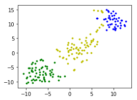

```python
result_0 = np.array([result[i] for i in range(len(hierarchical_example.labels_)) if hierarchical_example.labels_[i] == 0])
result_1 = np.array([result[i] for i in range(len(hierarchical_example.labels_)) if hierarchical_example.labels_[i] == 1])
result_2 = np.array([result[i] for i in range(len(hierarchical_example.labels_)) if hierarchical_example.labels_[i] == 2])

plt.scatter(result_0[:,0], result_0[:,1], c='y', linewidths=0.5, s=10)
plt.scatter(result_1[:,0], result_1[:,1], c='g', linewidths=0.5, s=10)
plt.scatter(result_2[:,0], result_2[:,1], c='b', linewidths=0.5, s=10)
flg_hierarchical = plt
```

## Gaussian Mixture Model

- sklearn.mixture.GaussianMixture
- input
  - k clusters
  - data (n object with p attributes)

n_components  
The number of mixture components  
covariance_type  
‘full’, ‘tied’, ‘diag’, ‘spherical’  
random_state

```python
from sklearn.mixture import GaussianMixture
from sklearn.preprocessing import MinMaxScaler

gmm_data = MinMaxScaler().fit_transform(two_mode_data)
gmm = GaussianMixture(n_components=3,random_state=0)
gmm.fit(gmm_data)
gmm_labels = gmm.predict(gmm_data)
print (gmm_labels)
```

```
[2 2 2 2 2 2 2 2 2 2 2 2 2 2 2 2 2 2 2 2 2 2 2 2 2 2 2 2 2 2 2 2 2 2 2 2 2
 2 2 2 2 2 2 2 2 2 2 2 2 2 2 2 2 2 2 2 2 2 2 1 1 0 1 1 1 1 2 1 1 1 1 2 1 2
 1 1 1 1 1 1 1 2 1 0 1 1 1 1 1 1 1 1 1 1 1 1 1 1 1 1 1 1 1 1 1 1 1 1 1 1 1
 1 1 1 1 1 1 1 1 1 1 1 1 1 1 1 1 1 1 1 0 0 0 0 0 0 0 0 0 0 0 0 0 0 0 0 0 0
 0 0 0 0 0 0 0 0 0 0 0 0 0 0 0 0 0 0 0 0 0 0 0 0 0 0 0 0 0 0]
```

```python
from sklearn.manifold import TSNE

model = TSNE(n_components=2, random_state=0)
result = model.fit_transform(gmm_data)
print (result)
```

```
[[-9.41307545e+00 -5.36982441e+00]
 [-5.27640247e+00 -5.49918079e+00]
 [-7.33208895e+00 -8.36583614e+00]
 [-9.86803055e+00 -8.85849667e+00]
 [-2.71293235e+00 -8.07800102e+00]
 [-8.74751949e+00 -9.56701660e+00]
 [-6.87087154e+00 -6.61375618e+00]
 [-6.07435513e+00 -6.53456926e+00]
 [-7.68953991e+00 -7.03216743e+00]
 [-8.51977444e+00 -6.58942795e+00]
 [-7.97146225e+00 -9.49195194e+00]
 [-5.53940439e+00 -6.96382809e+00]
 [-6.14226818e+00 -7.58807802e+00]
 [-9.94132137e+00 -1.05815887e+01]
 [-9.56696224e+00 -1.01469898e+01]
 [-5.87846708e+00 -9.06414223e+00]
 [-6.34167147e+00 -9.82225227e+00]
 [-5.71603203e+00 -9.83495331e+00]
 [-8.52365685e+00 -1.03194447e+01]
 [-7.94164467e+00 -3.64376426e+00]
 [-9.13688850e+00 -5.25335646e+00]
 [-6.13593769e+00 -2.62695193e+00]
 [-6.45533419e+00 -5.23342800e+00]
 [-5.27841616e+00 -4.71946764e+00]
 [-5.62069654e+00 -4.52530670e+00]
 [-2.25526690e+00 -8.29965019e+00]
 [-5.51274776e+00 -7.56508780e+00]
 [-4.55233908e+00 -6.10934210e+00]
 [-3.93887067e+00 -8.34850216e+00]
 [-6.96671963e+00 -5.86230040e+00]
 [-6.87722206e+00 -9.54773331e+00]
 [-7.72863102e+00 -9.33568954e+00]
 [-4.41442728e+00 -7.77206182e+00]
 [-4.72162676e+00 -9.87759686e+00]
 [-4.51377773e+00 -7.14347553e+00]
 [-6.30863476e+00 -4.99403048e+00]
 [-3.80580735e+00 -7.34558010e+00]
 [-4.16054487e+00 -6.64207315e+00]
 [-4.08926249e+00 -5.78821754e+00]
 [-8.50391388e+00 -3.38012290e+00]
```

[output cut: 123 more lines]

```
 [ 9.20722485e+00  9.89115810e+00]
 [ 9.06734848e+00  1.20329800e+01]
 [ 1.14944992e+01  1.02923317e+01]
 [ 9.65223980e+00  1.28086529e+01]
 [ 9.20773888e+00  1.15515003e+01]
 [ 8.94358253e+00  1.28257837e+01]
 [ 9.89676476e+00  1.44290972e+01]
 [ 8.72419167e+00  9.59697056e+00]
 [ 8.50311947e+00  1.09170380e+01]
 [ 8.88660622e+00  1.21004219e+01]
 [ 1.18410072e+01  1.12449503e+01]
 [ 1.01385603e+01  1.18877850e+01]
 [ 1.01812410e+01  1.29515247e+01]
 [ 8.11066532e+00  1.17585115e+01]
 [ 1.12092991e+01  1.21997452e+01]]
```

```python
from matplotlib.font_manager import FontProperties
import matplotlib.pyplot as plt
import numpy as np
%matplotlib inline
# Get current size
fig_size = plt.rcParams["figure.figsize"]
# Set figure width to 12 and height to 9
fig_size[0] = 4.0
fig_size[1] = 3.0
plt.rcParams["figure.figsize"] = fig_size
```

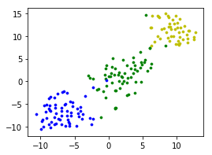

```python
result_0 = np.array([result[i] for i in range(len(gmm_labels)) if gmm_labels[i] == 0])
result_1 = np.array([result[i] for i in range(len(gmm_labels)) if gmm_labels[i] == 1])
result_2 = np.array([result[i] for i in range(len(gmm_labels)) if gmm_labels[i] == 2])

plt.scatter(result_0[:,0], result_0[:,1], c='y', linewidths=0.5, s=10)
plt.scatter(result_1[:,0], result_1[:,1], c='g', linewidths=0.5, s=10)
plt.scatter(result_2[:,0], result_2[:,1], c='b', linewidths=0.5, s=10)
flg_gmm = plt
```